# assignment4

TemmirlanZholaman

2023-02-23

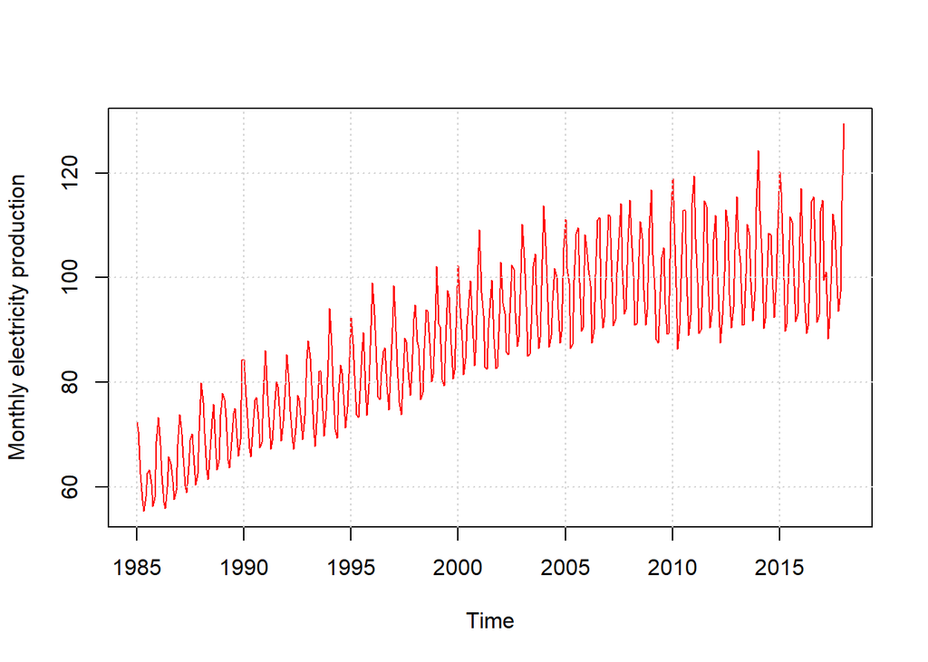

I will keep the entire dataset.

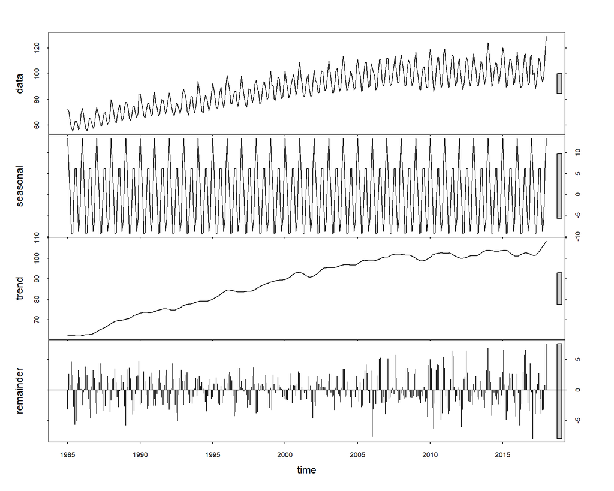

Box-Cox transformation with optimal $\lambda$:

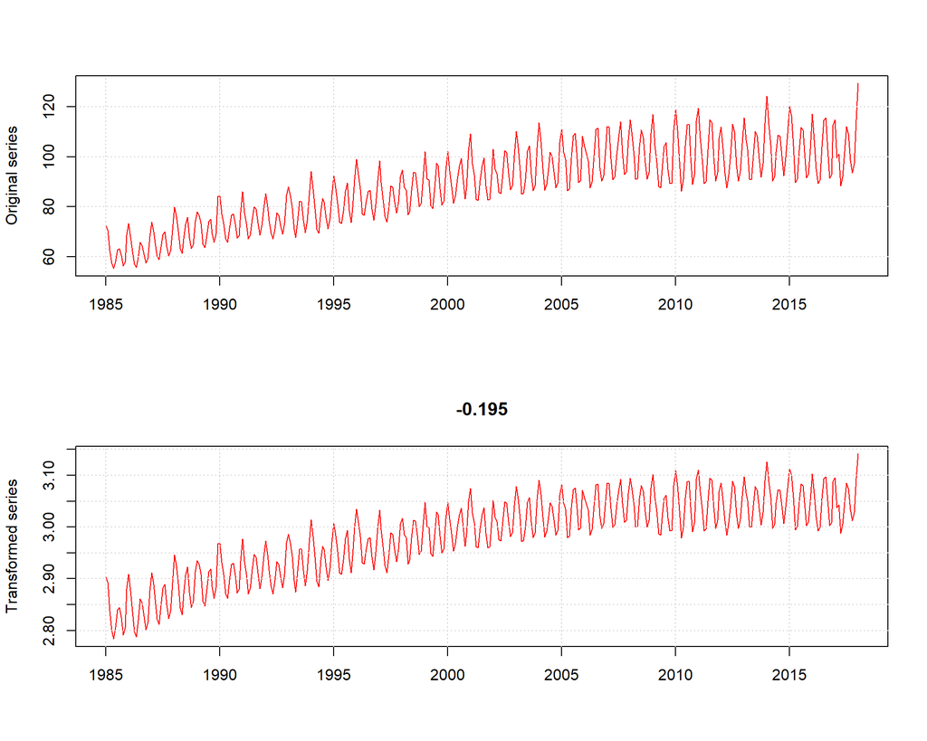

```
## Series: tSeries
## ARIMA(1,1,1)(1,1,2)[12]
## Box Cox transformation: lambda= -0.1949706
##
## Coefficients:
##          ar1      ma1     sar1     sma1     sma2
##       0.5218  -0.9210  -0.4697  -0.2717  -0.4883
## s.e.  0.0544   0.0246   0.2198   0.2060   0.1665
##
## sigma^2 = 0.0001021:  log likelihood = 1214.79
## AIC=-2417.58   AICc=-2417.35   BIC=-2393.87
```

ARIMA(1,1,1)(1,1,2)$_{12}$ is selected. Here are the residuals:

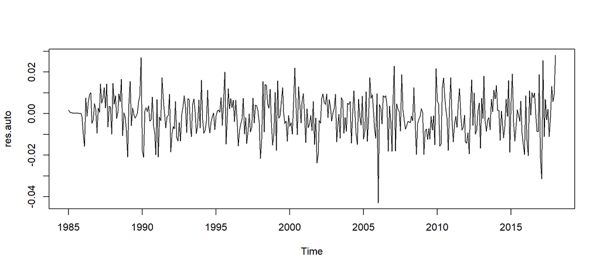

At the beginning residuals are not defined properly; let’s cut the first 12 before proceeding with residual analysis.

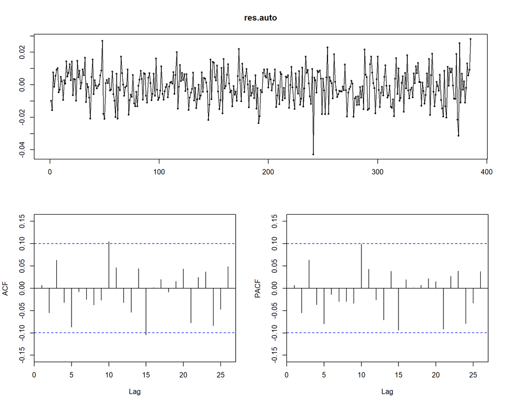

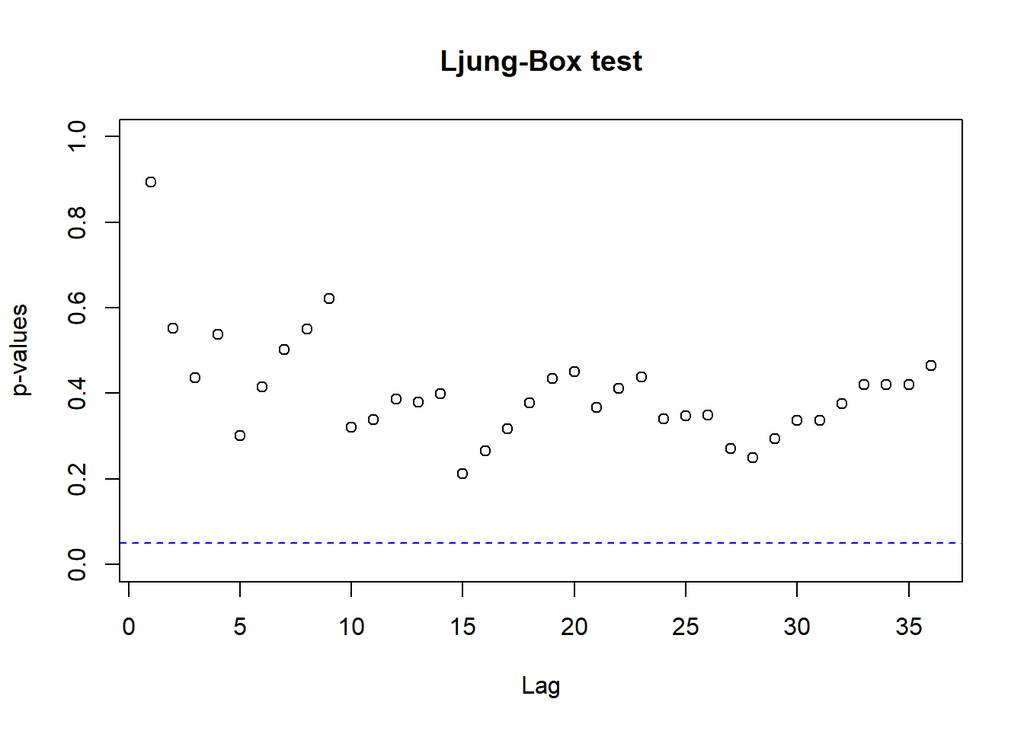

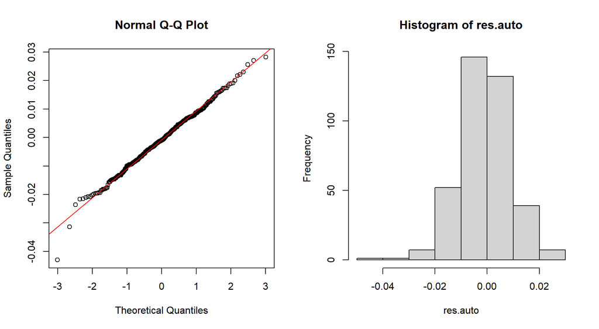

| Hypothesis | Test | Result | P-value |
| --- | --- | --- | --- |
| Normality | Shapiro-Wilk | not rejected | 0.2076447 |
| Unbiasedness | Wilcoxon | not rejected | 0.116778 |
| Stationarity | KPSS | not rejected | 0.1 |

Fitting the selected model to the first $T-D$ points of the series to check the accuracy of the forecast on the last $D$ points:

```
##                      ME     RMSE      MAE        MPE     MAPE      MASE
## Training set -0.2185157 2.120217 1.589829 -0.2558724 1.767807 0.5709927
## Test set     -1.9779814 4.143587 3.178738 -2.0607983 3.111027 1.1416549
##                     ACF1 Theil's U
## Training set 0.003058551        NA
## Test set     0.410571967 0.3998975
```

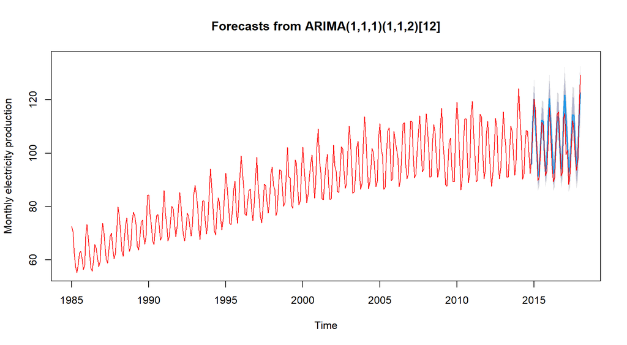

### Manual model tuning

The series is nonstationary (p<0.01, KPSS test) and seasonal; let’s do seasonal differencing:

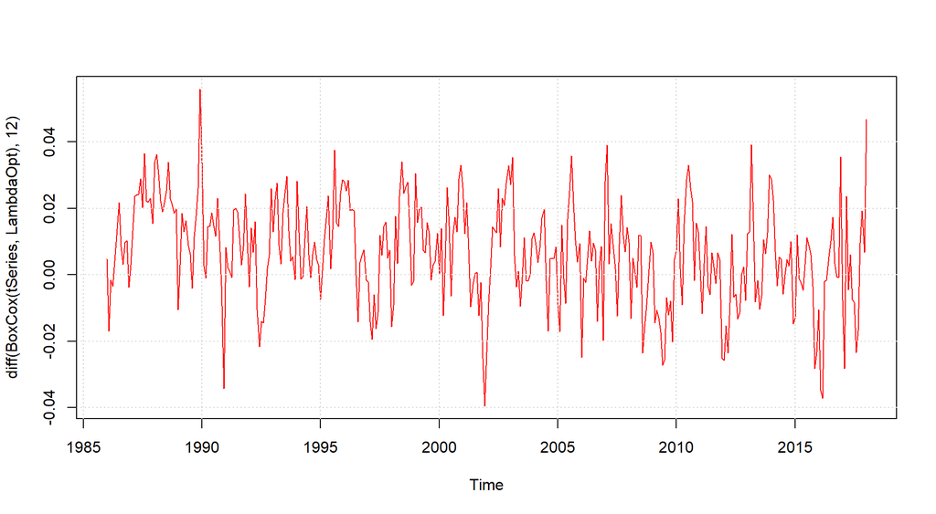

Still not stationary (p<0.01, KPSS test. Let’s do another, nonseasonal differencing:

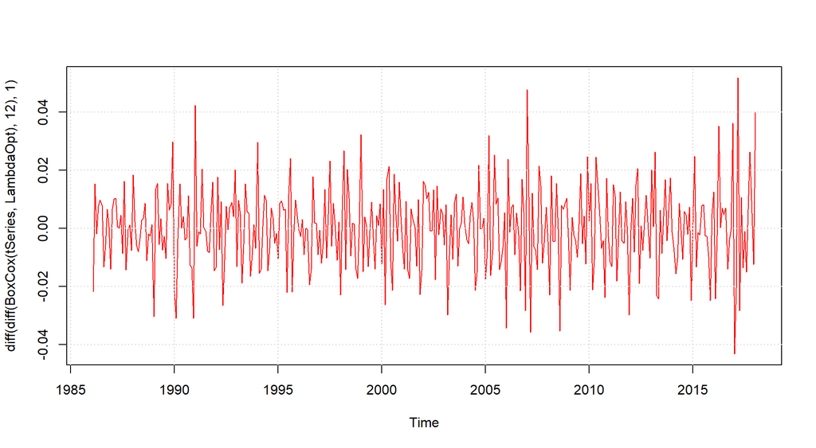

The hypothesis of stationarity is now not rejected (p>0.1, KPSS test).

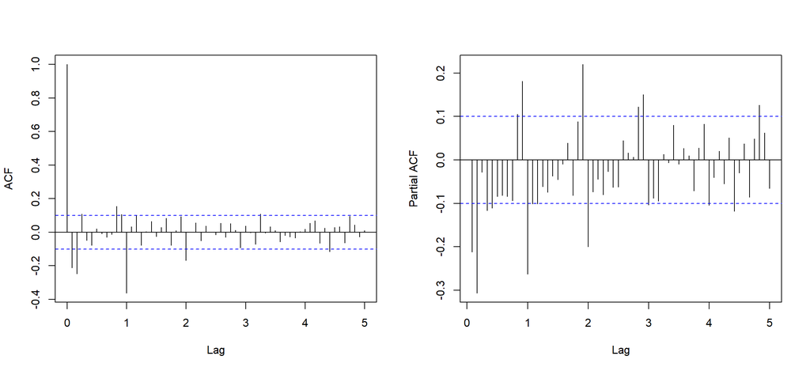

Autocorrelation is significantly different from 0 for lags 1, 2, 3, 10, 11, 12, 24, 39 and 53 Since 24 is maximal significant seasonal lag, we could use $Q = 24/12 = 2$ as an initial approximation. Maximal significant lag before 12 is 11, hence the starting value $q=11$.

Partial autocorrelation is significantly different from 0 for lags 1, 2, 4, 5, 10, 11, 12, 13(debatable), 14, 23, 24, 34, 35 ,36, 48, 53, 58 Following the same logic as above, we select initial values $P=4$, $p=11$.

```
## Series: tSeries
## ARIMA(2,1,1)(0,1,1)[12]
## Box Cox transformation: lambda= -0.1949706
##
## Coefficients:
##          ar1      ar2      ma1     sma1
##       0.5262  -0.0263  -0.9146  -0.8301
## s.e.  0.0577   0.0557   0.0285   0.0334
##
## sigma^2 = 0.000103:  log likelihood = 1212.58
## AIC=-2415.16   AICc=-2415   BIC=-2395.4
```

The lowest AICc has ARIMA(2,1,1)(0,1,1)$_{12}$. Does it have good residuals?

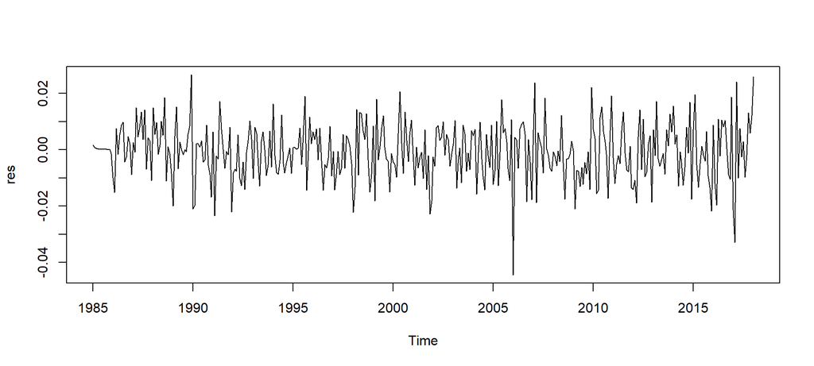

Residuals are OK I think, lets explore without first 12 months

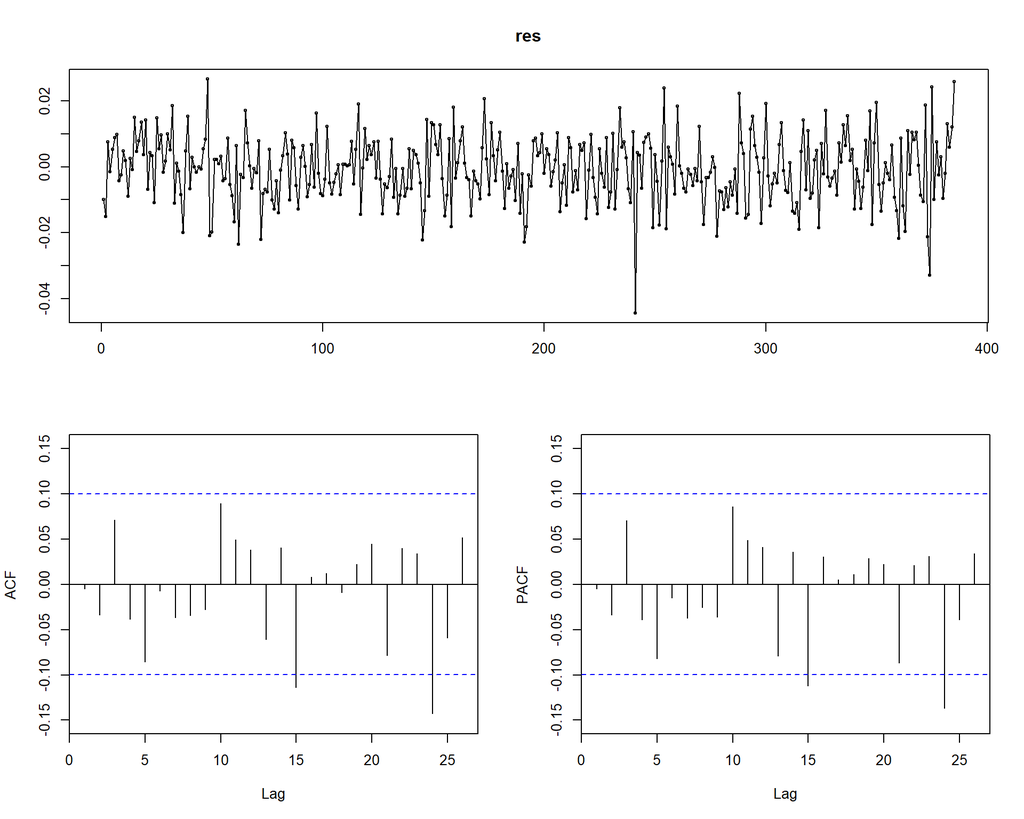

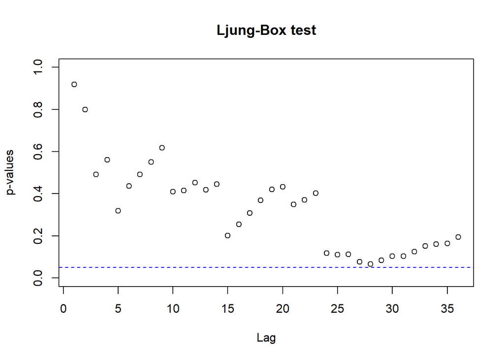

Q-Q plot and histogram of the residuals:

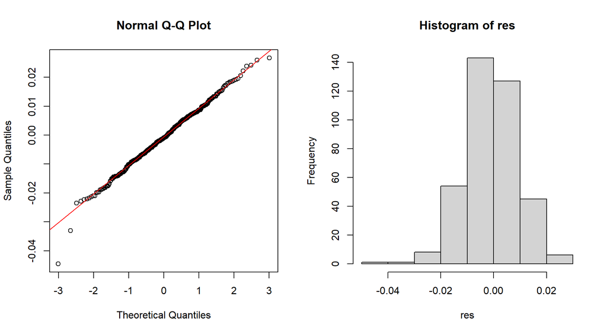

| Hypothesis | Test | Result | P-value |
| --- | --- | --- | --- |
| Normality | Shapiro-Wilk | not rejected | 0.1185809 |
| Unbiasedness | Wilcoxon | not rejected | 0.1465751 |
| Stationarity | KPSS | not rejected | 0.1 |

Fitting the selected model to the first $T-D$ points of the series to check the accuracy of the forecast on the last $D$ points:

```
##                      ME     RMSE      MAE        MPE     MAPE      MASE
## Training set -0.2069862 2.142320 1.601978 -0.2451413 1.778909 0.5753559
## Test set     -1.7216847 4.043499 3.095553 -1.8133981 3.015080 1.1117787
##                     ACF1 Theil's U
## Training set -0.01467359        NA
## Test set      0.41537658 0.3880479
```

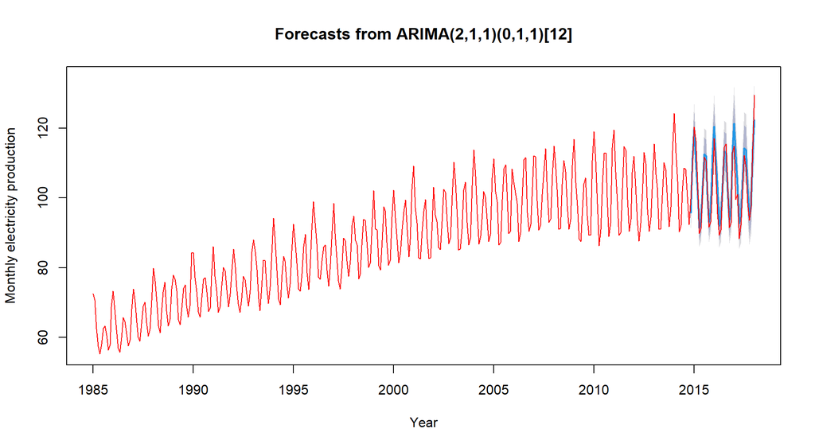

### ETS model

```
## ETS(A,A,A)
##
## Call:
##  ets(y = tSeries, lambda = LambdaOpt, biasadj = T)
##
##   Box-Cox transformation: lambda= -0.195
##
##   Smoothing parameters:
##     alpha = 0.6725
##     beta  = 1e-04
##     gamma = 0.0213
##
##   Initial states:
##     l = 2.8469
##     b = 5e-04
##     s = 0.0294 -0.0295 -0.0446 -0.013 0.0266 0.0287
##            -0.0048 -0.0412 -0.041 -8e-04 0.0306 0.0596
##
##   sigma:  0.0108
##
##       AIC      AICc       BIC
## -1203.515 -1201.900 -1135.788
```

Residuals:

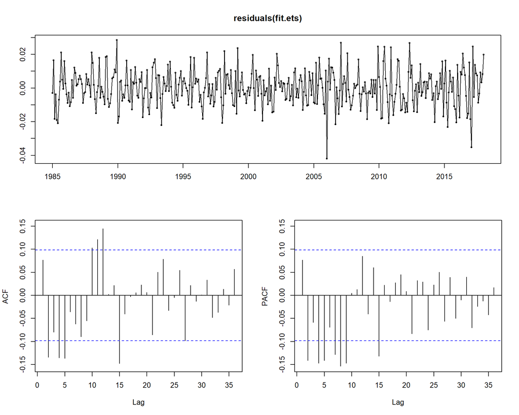

Ljung-Box test p-values for them:

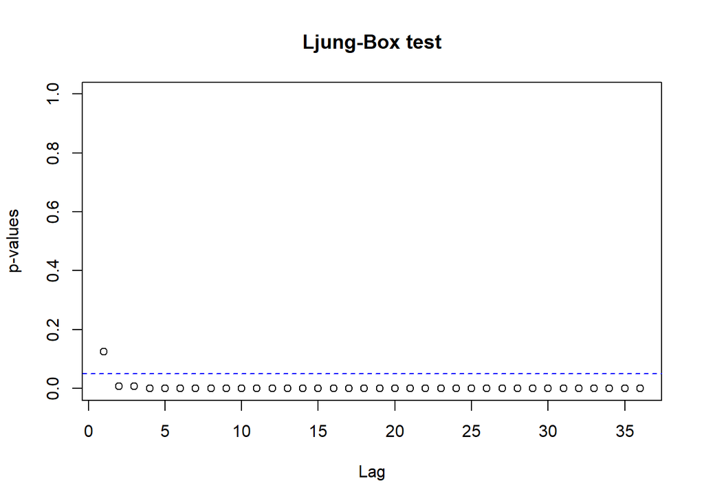

The residuals are correlated, the model does not take into account all the structure in the data.

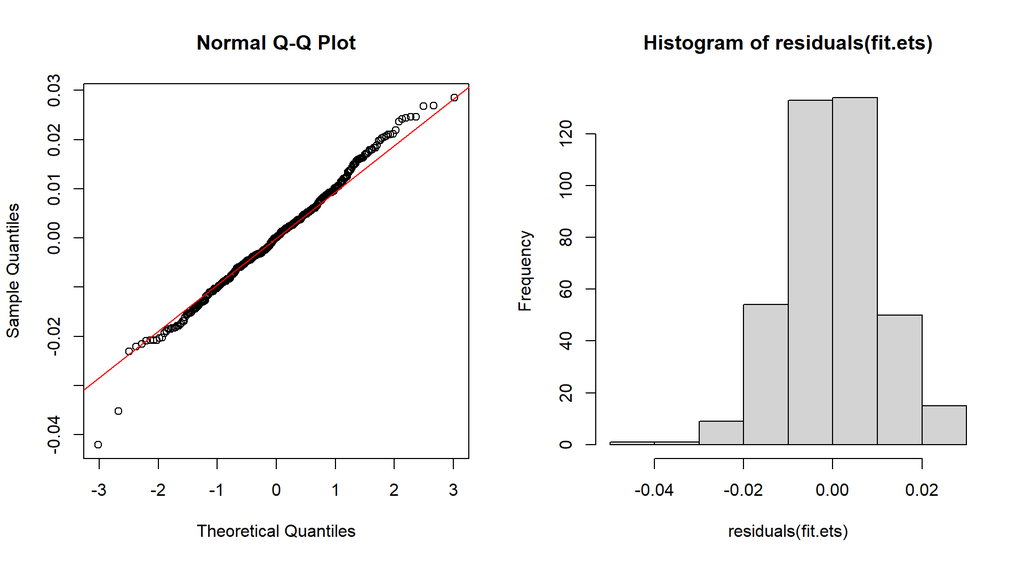

| Hypothesis | Test | Result | P-value |
| --- | --- | --- | --- |
| Normality | Shapiro-Wilk | not rejected | 0.1041111 |
| Unbiasedness | Wilcoxon | not rejected | 0.9734992 |
| Stationarity | KPSS | not rejected | 0.1 |

Fitting the selected model to the first $T-D$ points of the series to check the accuracy of the forecast on the last $D$ points:

```
##                        ME     RMSE      MAE          MPE     MAPE      MASE
## Training set  0.004925951 2.219565 1.673978 -0.006845191 1.885980 0.6012149
## Test set     -2.581730197 4.852593 3.760388 -2.675949674 3.721299 1.3505567
##                    ACF1 Theil's U
## Training set 0.09764362        NA
## Test set     0.52630864 0.4744565
```

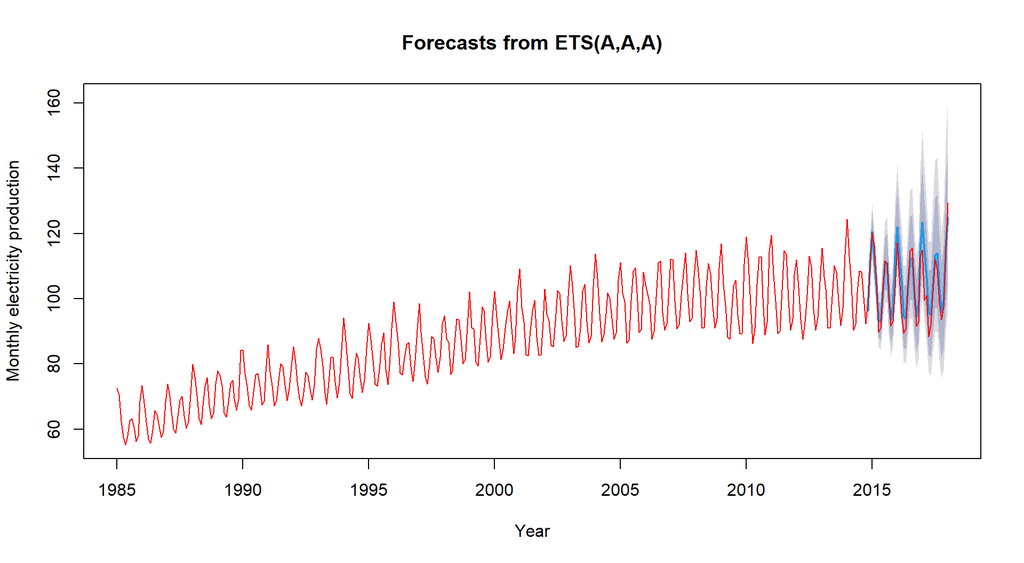

## Final model selection

Comparing the residuals of two ARIMAs:

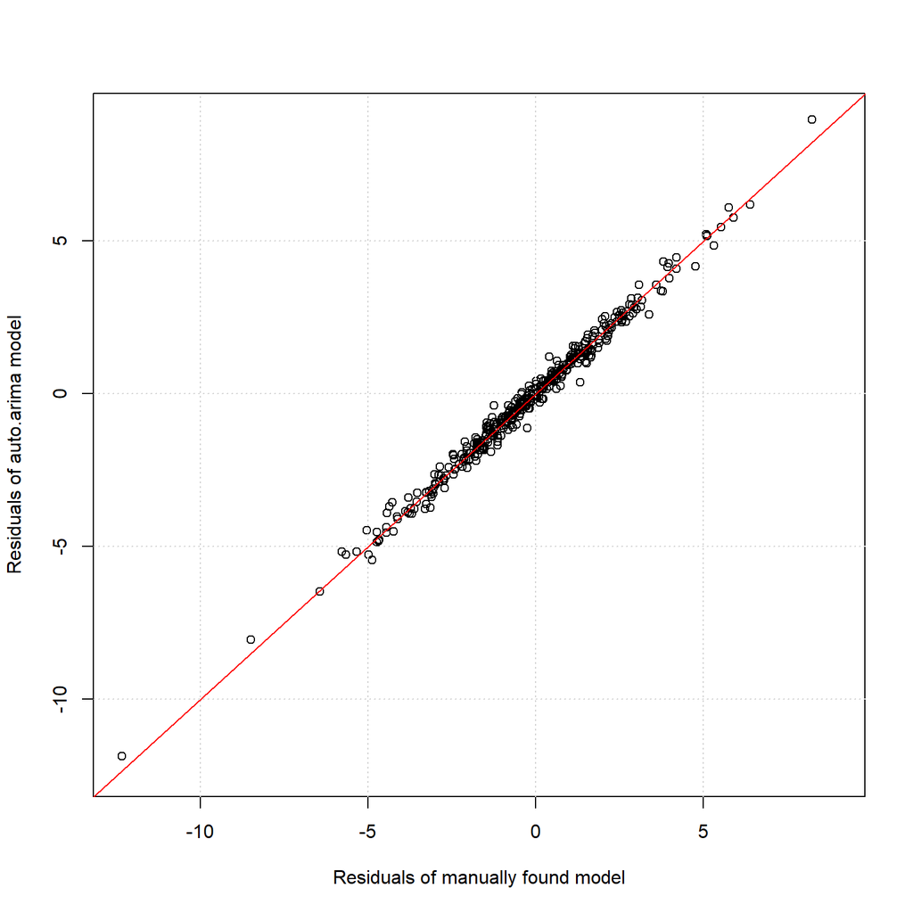

```
##
##  Diebold-Mariano Test
##
## data:  resres.auto
## DM = 1.0192, Forecast horizon = 1, Loss function power = 2, p-value =
## 0.3087
## alternative hypothesis: two.sided
```

Diebold-Mariano test does not find the differences between forecasting errors of two ARIMAs significant. The residuals of two models have the same properties. While their AICc score is nearly the same, manually tuned ARIMA shows smaller losses on test set and lower Theil’s U, so we stick with it.

Now let’s compare it to ets model Comparing the residuals of the best ARIMA and the best ETS models:

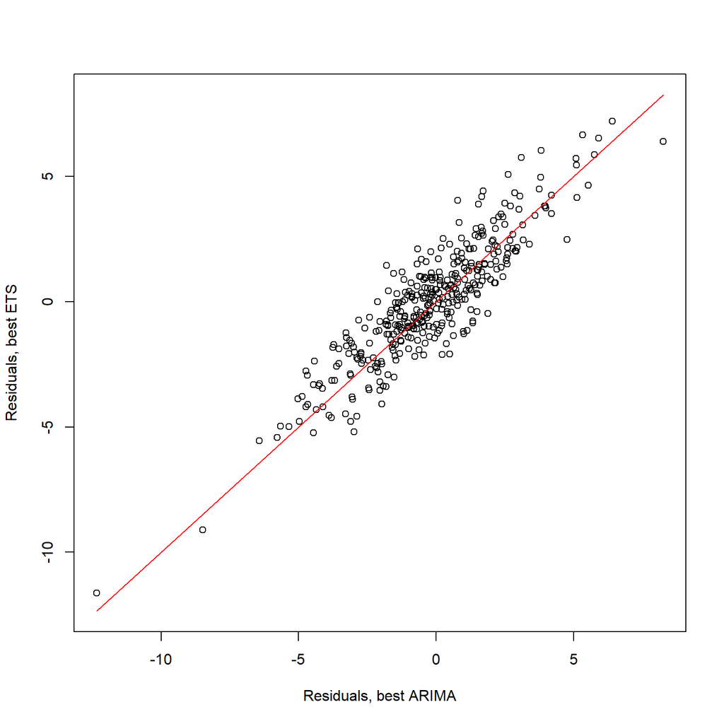

```
##
##  Diebold-Mariano Test
##
## data:  resres.ets
## DM = -0.78136, Forecast horizon = 1, Loss function power = 2, p-value =
## 0.4351
## alternative hypothesis: two.sided
```

```
##
##  Diebold-Mariano Test
##
## data:  resres.ets
## DM = -0.78136, Forecast horizon = 1, Loss function power = 2, p-value =
## 0.2175
## alternative hypothesis: less
```

Diebold-Mariano Test cannot say whether ARIMA is better than ETS model. ETS model had good training losses, but worse test losses. Also its Theul’s U is much bigger than ARIMA’s one, and its residuals are auto correlated, so I want to stick to ARIMA model more. Finally, by observing predictions on the test set, it can be observed, that ETS model overpredicts most of the times, while ARIMA’s predictions look better in general. So I will make a forecast with manually tuned ARIMA.

## Forecast

```
##          Point Forecast     Lo 80     Hi 80     Lo 95     Hi 95
## Feb 2018      114.28614 110.57099 118.05864 108.68501 120.14093
## Mar 2018      104.68087 100.76459 108.66688  98.78917 110.88107
## Apr 2018       92.47672  88.92675  96.09157  87.13838  98.10213
## May 2018       94.01042  90.30532  97.78508  88.44129  99.88732
## Jun 2018      104.91890 100.63383 109.28741  98.48204 111.72490
## Jul 2018      114.41978 109.61498 119.32084 107.20583 122.05957
## Aug 2018      113.57635 108.76797 118.48187 106.35811 121.22431
## Sep 2018      102.47173  98.18097 106.84819  96.02923 109.29339
## Oct 2018       94.16767  90.25554  98.15732  88.29283 100.38545
## Nov 2018       97.47920  93.36893 101.67216  91.30849 104.01573
## Dec 2018      113.11863 108.17068 118.16992 105.69543 120.99903
## Jan 2019      122.58691 117.09822 128.19299 114.35617 131.33705
## Feb 2019      111.57051 106.51575 116.73469 103.99224 119.63293
## Mar 2019      103.88755  99.15831 108.71967  96.79798 111.43231
## Apr 2019       92.48694  88.31531  96.74847  86.23214  99.13949
## May 2019       94.35768  90.03845  98.77140  87.88347 101.24998
## Jun 2019      105.49683 100.51418 110.59204  98.03294 113.45874
## Jul 2019      115.15634 109.57367 120.86854 106.79818 124.08762
## Aug 2019      114.35099 108.76548 120.06711 105.98991 123.28993
## Sep 2019      103.17502  98.19133 108.27391  95.71306 111.14670
## Oct 2019       94.81120  90.26720  99.45942  88.00646 102.07700
## Nov 2019       98.15424  93.37905 103.04063  91.00555 105.79494
## Dec 2019      113.92852 108.17792 119.81819 105.32643 123.14593
## Jan 2020      123.48063 117.09965 130.01969 113.94058 133.72014
## Feb 2020      112.36992 106.51442 118.37172 103.61715 121.77006
## Mar 2020      104.62209  99.15201 110.22933  96.44606 113.40499
## Apr 2020       93.12622  88.30471  98.06741  85.91800 100.86399
## May 2020       95.01305  90.02222 100.12961  87.55415 103.02829
## Jun 2020      106.24689 100.48952 112.15402  97.64860 115.50786
## Jul 2020      115.99037 109.53955 122.61354 106.36242 126.38093
## Aug 2020      115.17858 108.72498 121.80593 105.54823 125.57775
## Sep 2020      103.90675  98.14963 109.81709  95.31338 113.17809
## Oct 2020       95.47259  90.22423 100.85950  87.63714 103.92111
## Nov 2020       98.84425  93.32888 104.50747  90.61313 107.72959
## Dec 2020      114.75467 108.11168 121.58261 104.84971 125.47805
## Jan 2021      124.39151 117.01984 131.97344 113.40660 136.30683
## Feb 2021      113.18401 106.44091 120.12049 103.13715 124.08662
## Mar 2021      105.36981  99.08008 111.84029  95.99891 115.54052
## Apr 2021       93.77669  88.23753  99.47329  85.52182 102.72832
```

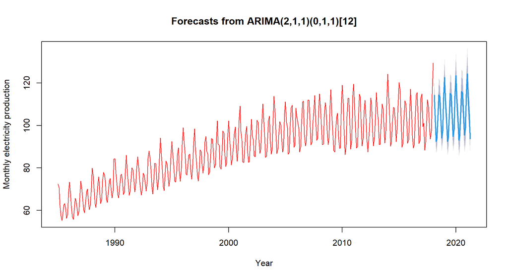